# Árboles de clasificación y regresión con Rpart

## 2.5 Evaluando el rendimiento

Para evaluar adecuadamente el rendimiento de un árbol de clasificación en estos datos, debemos estimar el error de prueba en lugar de simplemente calcular el error de entrenamiento.

```r
set.seed(2)
train <- sample(1:nrow(Carseats), 350)
Carseats.test <- Carseats[-train, ]
High.test <- High[-train]
tree.carseats <- rpart(High ~ . - Sales, Carseats[train, ],
  method = "class",
  control = rpart.control(xval = 10, minbucket = 2, cp = 0)
)
printcp(tree.carseats)
```

```
##
## Classification tree:
## rpart(formula = High ~ . - Sales, data = Carseats[train, ], method = "class",
##     control = rpart.control(xval = 10, minbucket = 2, cp = 0))
##
## Variables actually used in tree construction:
## [1] Advertising Age         CompPrice   Education   Income      Population
## [7] Price       ShelveLoc   US
##
## Root node error: 142/350 = 0.40571
##
## n= 350
##
##           CP nsplit rel error  xerror     xstd
## 1  0.2746479      0   1.00000 1.00000 0.064692
## 2  0.1267606      1   0.72535 0.72535 0.060041
## 3  0.0457746      2   0.59859 0.69014 0.059155
## 4  0.0352113      4   0.50704 0.66901 0.058588
## 5  0.0281690      5   0.47183 0.68310 0.058969
## 6  0.0211268      8   0.38028 0.68310 0.058969
## 7  0.0140845      9   0.35915 0.65493 0.058195
## 8  0.0123239     15   0.27465 0.64789 0.057994
## 9  0.0070423     19   0.22535 0.64085 0.057789
## 10 0.0000000     31   0.14085 0.64085 0.057789
```

- Nota que los errores se expresan en términos relativos con respecto a la primera fila.
- Las columnas de error se han escalado de modo que el primer nodo tenga un error de 1. Dado que en este ejemplo el modelo sin divisiones debe hacer 142/350 clasificaciones incorrectas, multiplica las columnas 3-5 por 142 para obtener un resultado en términos de error absoluto. (Los cálculos se realizan en la escala de error absoluto y se imprimen en la escala relativa).

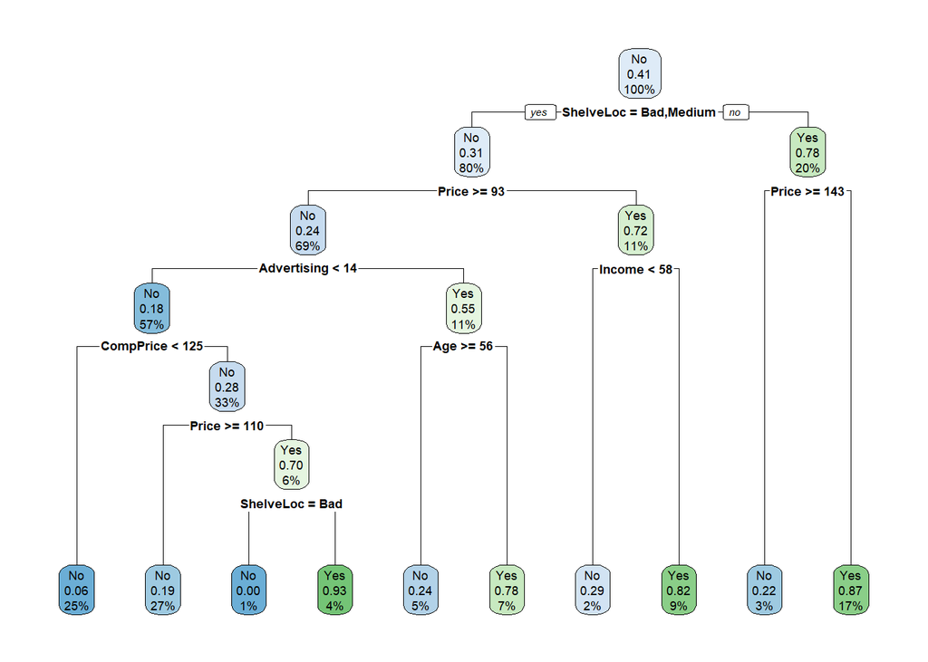

```r
fit7 <- prune(tree.carseats, cp = 0.021)
rpart.plot(fit7)
```

```r
tree.pred <- predict(fit7, Carseats.test, type = "class")
table(tree.pred, High.test)
```

```
##          High.test
## tree.pred No Yes
##       No  24   6
##       Yes  4  16
```

```r
print(paste0("The hit rate of this tree on test is ", MLmetrics::Accuracy(tree.pred, High.test)))
```

```
## [1] "The hit rate of this tree on test is 0.8"
```

```r
print(paste0("The estimated crossvalidation error of this tree is ", 0.654 * 142 / 350))
```

```
## [1] "The estimated crossvalidation error of this tree is 0.265337142857143"
```